# Hidden vs Visible Resources in the Survival Game (Experiment 1)

Scott Claessens

2020-05-27

# 0. Setup

Load the data from Experiment 1.

| ID | Group | IDinGroup | Condition | Payment | Age | Sex | Language | rounds_survived | total_cattle_lost | overall_total_amount_requested | overall_total_amount_received | overall_total_amount_given | overall_received_given_totaldiff | overall_mean_amount_requested | overall_mean_amount_received | overall_mean_amount_given | overall_num_shocks | overall_num_requests_made | overall_num_requests_when_under_threshold | overall_num_requests_responded_to | overall_repetitive_giving | overall_repetitive_asking | payment_for_lobby | payment_from_game | attention | feel_bad_ask | fairness | risk_pooling_true | risk_pooling_false | … |
| --- | --- | --- | --- | --- | --- | --- | --- | --- | --- | --- | --- | --- | --- | --- | --- | --- | --- | --- | --- | --- | --- | --- | --- | --- | --- | --- | --- | --- | --- | --- |
| 1 | 1 | 2 | 1 | 3.72 | 44 | 1 | 1 | 25 | 24 | 0 | 0 | 0 | 0 | 0.0000000 | 0.00000000 | 0.00000000 | 1 | 0 | 0 | 0 | 0 | 0 | 0 | 251 | 6 | 3 | 2 | 2 | 4 | … |
| 2 | 1 | 1 | 1 | 1.98 | 39 | 0 | 1 | 11 | 30 | 35 | 0 | 0 | 0 | 3.1818182 | 0.00000000 | 0.00000000 | 3 | 9 | 5 | 0 | 0 | 0 | 1 | 74 | 6 | 3 | 3 | 3 | 3 | … |
| 3 | 2 | 1 | 1 | 3.69 | 34 | 1 | 1 | 25 | 21 | 4 | 2 | 3 | -1 | 0.1600000 | 0.08000000 | 0.12000000 | 1 | 3 | 0 | 3 | 1 | 0 | 3 | 244 | 3 | 1 | 4 | 4 | 5 | … |
| 4 | 2 | 2 | 1 | 2.50 | 29 | 1 | 1 | 19 | 63 | 16 | 3 | 2 | 1 | 0.8421053 | 0.15789474 | 0.10526316 | 6 | 7 | 4 | 2 | 0 | 4 | 0 | 128 | 6 | 4 | 4 | 4 | 2 | … |
| 5 | 3 | 2 | 1 | 3.25 | 42 | 1 | 1 | 25 | 63 | 32 | 7 | 6 | 1 | 1.2800000 | 0.28000000 | 0.24000000 | 4 | 6 | 1 | 3 | 0 | 2 | 1 | 201 | 6 | 4 | 5 | 4 | 2 | … |
| 6 | 3 | 1 | 1 | 3.81 | 39 | 1 | 1 | 25 | 33 | 16 | 6 | 7 | -1 | 0.6400000 | 0.24000000 | 0.28000000 | 2 | 3 | 0 | 5 | 2 | 0 | 0 | 259 | 6 | 2 | 4 | 4 | 3 | … |
| 7 | 4 | 2 | 1 | 3.83 | 28 | 1 | 1 | 25 | 37 | 65 | 10 | 0 | 10 | 2.6000000 | 0.40000000 | 0.00000000 | 2 | 3 | 0 | 0 | 0 | 2 | 1 | 259 | 6 | 1 | 1 | 1 | 5 | … |
| 8 | 4 | 1 | 1 | 1.39 | 28 | 1 | 1 | 3 | 13 | 37 | 0 | 10 | -10 | 12.3333333 | 0.00000000 | 3.33333333 | 1 | 3 | 3 | 1 | 0 | 0 | 0 | 16 | 6 | 1 | 2 | 1 | 4 | … |
| 9 | 5 | 2 | 1 | 3.00 | 28 | 1 | 1 | 25 | 63 | 15 | 9 | 9 | 0 | 0.6000000 | 0.36000000 | 0.36000000 | 6 | 6 | 2 | 5 | 2 | 4 | 1 | 176 | 6 | 2 | 3 | 4 | 4 | … |
| 10 | 5 | 1 | 1 | 4.02 | 31 | 0 | 1 | 25 | 39 | 22 | 9 | 9 | 0 | 0.8800000 | 0.36000000 | 0.36000000 | 1 | 11 | 0 | 5 | 3 | 6 | 0 | 280 | 3 | 3 | 4 | 2 | 4 | … |

[output cut: 72 more lines]

Each row is a different participant in the study (there were 82). Columns 1-35 are variables that summarise the whole session, while the rest of the columns specify the events that occurred in each of the 25 rounds.

# 1. Binomial - Number of shocks

We’ll trim the dataset, to make it more manageable.

| Condition | rounds_survived | overall_num_shocks |
| --- | --- | --- |
| 1 | 25 | 1 |
| 1 | 11 | 3 |
| 1 | 25 | 1 |
| 1 | 19 | 6 |
| 1 | 25 | 4 |
| 1 | 25 | 2 |
| 1 | 25 | 2 |
| 1 | 3 | 1 |
| 1 | 25 | 6 |
| 1 | 25 | 1 |

[output cut: 72 more lines]

In this dataset, Condition == 1 implies that the participant played the Survival Game in the ‘Hidden’ condition (i.e. resource holdings were hidden from their partner). Condition == 0 refers to the ‘Visible’ control condition.

We first test whether the probability of a shock occurring differs between the two conditions. All analyses use the `brm()` function. Learn more about the **brms** package [here](https://github.com/paul-buerkner/brms).

```
## function(d1.01) {
##   brm(data = d1.01, family = binomial,
##       overall_num_shocks | trials(rounds_survived) ~ 0 + Intercept + Condition,
##       prior = c(prior(normal(0, 1), class = b)),
##       sample_prior = TRUE,
##       iter = 2000, warmup = 1000, chains = 4, cores = 4,
##       seed = 2113)
## }
```

We set the `seed` to a random number, to make the results reproducible. Here are the priors that were set for this model.

| prior | class | coef | group | resp | dpar | nlpar | bound |
| --- | --- | --- | --- | --- | --- | --- | --- |
| normal(0, 1) | b |  |  |  |  |  |  |
|  | b | Condition |  |  |  |  |  |
|  | b | Intercept |  |  |  |  |  |

Let’s look at the results.

```
##  Family: binomial
##   Links: mu = logit
## Formula: overall_num_shocks | trials(rounds_survived) ~ 0 + Intercept + Condition
##    Data: d1.01 (Number of observations: 82)
## Samples: 4 chains, each with iter = 2000; warmup = 1000; thin = 1;
##          total post-warmup samples = 4000
##
## Population-Level Effects:
##           Estimate Est.Error l-95% CI u-95% CI Rhat Bulk_ESS Tail_ESS
## Intercept    -1.29      0.09    -1.46    -1.12 1.00     1212     1657
## Condition    -0.27      0.13    -0.52    -0.03 1.00     1240     1270
##
## Samples were drawn using sampling(NUTS). For each parameter, Bulk_ESS
## and Tail_ESS are effective sample size measures, and Rhat is the potential
## scale reduction factor on split chains (at convergence, Rhat = 1).
```

Plotting the parameters.

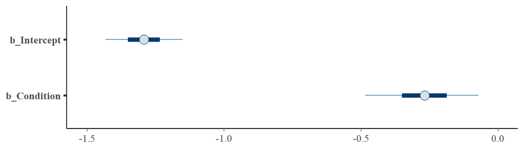

The Condition parameter is -0.27, and its 95% credible intervals do not cross 0, implying that the probability of a shock is smaller in the Hidden condition. But this is on the logit scale. Let’s convert the posterior samples onto the probability metric to confirm.

```r
post <- readd(post1.01)

visible_prob <- inv_logit_scaled(post$b_Intercept)
hidden_prob  <- inv_logit_scaled(post$b_Intercept + post$b_Condition)
difference   <- hidden_prob - visible_prob

quantile(difference,c(0.025,0.5,0.975)) %>% round(2)
```

```
##  2.5%   50% 97.5%
## -0.08 -0.04  0.00
```

The probability of a shock occurring is *very* slightly smaller in the Hidden condition.

# 2. Gaussian - Total amount of cattle lost due to shocks

Trim the dataset again.

| Condition | total_cattle_lost |
| --- | --- |
| 1 | 24 |
| 1 | 30 |
| 1 | 21 |
| 1 | 63 |
| 1 | 63 |
| 1 | 33 |
| 1 | 37 |
| 1 | 13 |
| 1 | 63 |
| 1 | 39 |

[output cut: 72 more lines]

We now fit a model to determine if the total amount of cattle lost due to shocks varies between conditions.

```
## function(d1.02) {
##   brm(data = d1.02, family = gaussian,
##       total_cattle_lost ~ 0 + Intercept + Condition,
##       prior = c(prior(normal(0, 100), class = b, coef = 'Intercept'),
##                 prior(normal(0, 5), class = b, coef = 'Condition')),
##       sample_prior = TRUE,
##       iter = 2000, warmup = 1000, chains = 4, cores = 4,
##       seed = 2113)
## }
```

The priors we used.

| prior | class | coef | group | resp | dpar | nlpar | bound |
| --- | --- | --- | --- | --- | --- | --- | --- |
|  | b |  |  |  |  |  |  |
| normal(0, 5) | b | Condition |  |  |  |  |  |
| normal(0, 100) | b | Intercept |  |  |  |  |  |
| student_t(3, 0, 19) | sigma |  |  |  |  |  |  |

The results.

```
##  Family: gaussian
##   Links: mu = identity; sigma = identity
## Formula: total_cattle_lost ~ 0 + Intercept + Condition
##    Data: d1.02 (Number of observations: 82)
## Samples: 4 chains, each with iter = 2000; warmup = 1000; thin = 1;
##          total post-warmup samples = 4000
##
## Population-Level Effects:
##           Estimate Est.Error l-95% CI u-95% CI Rhat Bulk_ESS Tail_ESS
## Intercept    46.89      2.46    42.19    51.78 1.00     2576     2436
## Condition     0.33      3.04    -5.67     6.33 1.00     2491     2517
##
## Family Specific Parameters:
##       Estimate Est.Error l-95% CI u-95% CI Rhat Bulk_ESS Tail_ESS
## sigma    17.40      1.40    14.83    20.39 1.00     3013     2753
##
## Samples were drawn using sampling(NUTS). For each parameter, Bulk_ESS
## and Tail_ESS are effective sample size measures, and Rhat is the potential
## scale reduction factor on split chains (at convergence, Rhat = 1).
```

Plot the parameters.

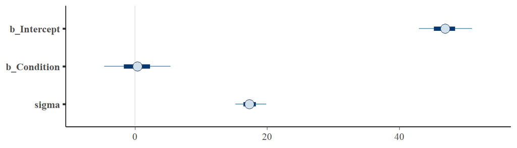

The total amount of cattle lost does not seem to vary between conditions.

# 3. Binomial - Probability of requesting

Get a long-format data frame with binary request decisions over all rounds. If request == NA, player has died and been removed from the game, so we drop those rows.

| ID | Group | Condition | round_number | request |
| --- | --- | --- | --- | --- |
| 1 | 1 | 1 | 1 | 0 |
| 2 | 1 | 1 | 1 | 1 |
| 3 | 2 | 1 | 1 | 0 |
| 4 | 2 | 1 | 1 | 1 |
| 5 | 3 | 1 | 1 | 1 |
| 6 | 3 | 1 | 1 | 1 |
| 7 | 4 | 1 | 1 | 1 |
| 8 | 4 | 1 | 1 | 1 |
| 9 | 5 | 1 | 1 | 0 |
| 10 | 5 | 1 | 1 | 1 |

[output cut: 990 more lines]

This leaves us with 1464 request decisions.

We now fit a varying intercept and slope model, with participants nested within groups. We only allow the slope for round number to vary, as participants completed multiple rounds (within-subjects) but only one condition, Hidden or Visible (between-subjects).

```
## function(d1.03) {
##   brm(data = d1.03, family = bernoulli,
##       request ~ 0 + Intercept + round_number + Condition
##       + (0 + Intercept + round_number | Group/ID),
##       prior = c(prior(normal(0, 1), class = b)),
##       sample_prior = TRUE,
##       iter = 2000, warmup = 1000, chains = 4, cores = 4,
##       control = list(adapt_delta = 0.9),
##       seed = 2113)
## }
```

Here are the priors for the model we just fitted.

| prior | class | coef | group | resp | dpar | nlpar | bound |
| --- | --- | --- | --- | --- | --- | --- | --- |
| lkj_corr_cholesky(1) | L |  |  |  |  |  |  |
|  | L |  | Group |  |  |  |  |
|  | L |  | Group:ID |  |  |  |  |
| normal(0, 1) | b |  |  |  |  |  |  |
|  | b | Condition |  |  |  |  |  |
|  | b | Intercept |  |  |  |  |  |
|  | b | round_number |  |  |  |  |  |
| student_t(3, 0, 10) | sd |  |  |  |  |  |  |
|  | sd |  | Group |  |  |  |  |
|  | sd | Intercept | Group |  |  |  |  |

[output cut: 4 more lines]

Now let’s see the results.

```
##  Family: bernoulli
##   Links: mu = logit
## Formula: request ~ 0 + Intercept + round_number + Condition + (0 + Intercept + round_number | Group/ID)
##    Data: d1.03 (Number of observations: 1464)
## Samples: 4 chains, each with iter = 2000; warmup = 1000; thin = 1;
##          total post-warmup samples = 4000
##
## Group-Level Effects:
## ~Group (Number of levels: 41)
##                             Estimate Est.Error l-95% CI u-95% CI Rhat Bulk_ESS Tail_ESS
## sd(Intercept)                   0.60      0.34     0.04     1.31 1.01      376     1118
## sd(round_number)                0.04      0.02     0.00     0.09 1.00      818     1693
## cor(Intercept,round_number)    -0.00      0.56    -0.93     0.95 1.00     1561     2457
##
## ~Group:ID (Number of levels: 82)
##                             Estimate Est.Error l-95% CI u-95% CI Rhat Bulk_ESS Tail_ESS
## sd(Intercept)                   1.65      0.28     1.13     2.23 1.00     1415     2644
## sd(round_number)                0.10      0.02     0.06     0.15 1.00     1012     1479
## cor(Intercept,round_number)    -0.70      0.15    -0.91    -0.33 1.00     1648     2294
##
## Population-Level Effects:
##              Estimate Est.Error l-95% CI u-95% CI Rhat Bulk_ESS Tail_ESS
## Intercept       -1.53      0.31    -2.13    -0.91 1.00     2541     2948
## round_number    -0.06      0.02    -0.10    -0.02 1.00     2970     2861
## Condition        0.94      0.38     0.18     1.66 1.00     2451     2192
##
## Samples were drawn using sampling(NUTS). For each parameter, Bulk_ESS
## and Tail_ESS are effective sample size measures, and Rhat is the potential
## scale reduction factor on split chains (at convergence, Rhat = 1).
```

Plotting the parameters.

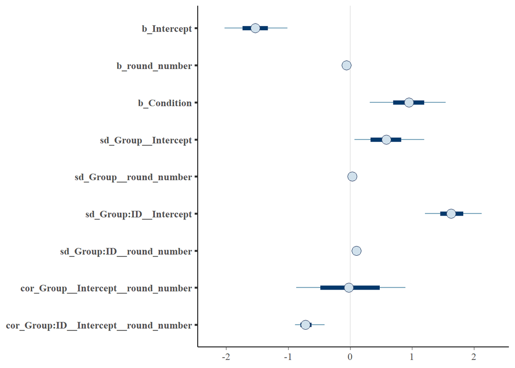

Trace plots to make sure Stan sampled efficiently.

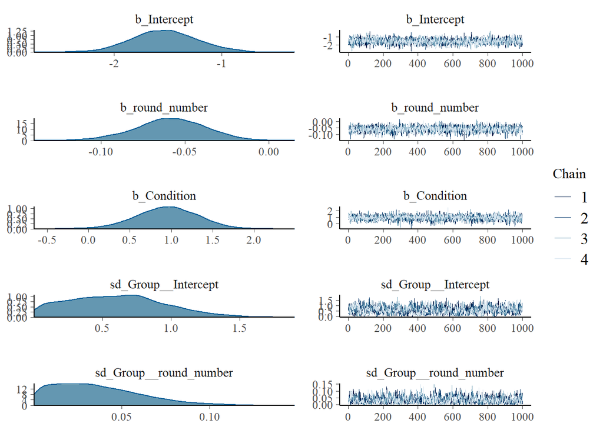

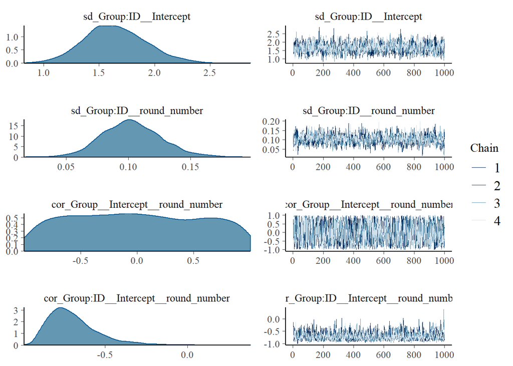

Looks like Stan sampled efficiently.

In this model, the fixed effect of condition is 0.94, with 95% credible intervals above 0. This implies that the probability of requesting was greater in the Hidden condition. However, this is on the logit scale. Let’s sample from the posterior and convert to the probability scale.

```r
post <- readd(post1.03)

visible_prob <- inv_logit_scaled(post$b_Intercept)

visible_prob %>%
  median() %>%
  round(2)
```

```
## [1] 0.18
```

```r
hidden_prob  <- inv_logit_scaled(post$b_Intercept + post$b_Condition)

hidden_prob %>%
  median() %>%
  round(2)
```

```
## [1] 0.36
```

```r
difference <- hidden_prob - visible_prob

quantile(difference,c(0.025,0.5,0.975)) %>% round(2)
```

```
##  2.5%   50% 97.5%
##  0.04  0.18  0.33
```

The absolute probability difference between the conditions is +0.18 (median), with 95% CIs above 0. Participants were more likely to request from their partner in the Hidden condition.

We compute a Bayes factor for this difference between probabilities. This will be the inverse of the Bayes factor for alternative hypothesis that the two conditions are equal.

```
## [1] 7.44
```

This Bayes factor implies moderate support for the hypothesis that the probabilities differ across conditions.

# 4. Binomial - Probability of requesting when above the minimum threshold

As before, get a long-format data frame with binary request decisions over all rounds. If request == NA, player has died and been removed from the game, so we drop those rows. However, we also filter out rows in which the player was below the minimum survival threshold (64 cattle).

| ID | Group | Condition | round_number | herd_size_after_shock | request |
| --- | --- | --- | --- | --- | --- |
| 1 | 1 | 1 | 1 | 73 | 0 |
| 2 | 1 | 1 | 1 | 72 | 1 |
| 3 | 2 | 1 | 1 | 72 | 0 |
| 5 | 3 | 1 | 1 | 68 | 1 |
| 6 | 3 | 1 | 1 | 74 | 1 |
| 7 | 4 | 1 | 1 | 68 | 1 |
| 9 | 5 | 1 | 1 | 69 | 0 |
| 10 | 5 | 1 | 1 | 71 | 1 |
| 11 | 6 | 1 | 1 | 72 | 0 |
| 12 | 6 | 1 | 1 | 72 | 0 |

[output cut: 990 more lines]

This leaves us with 1284 request decisions.

Fit the varying intercept and slope model, with participants nested within groups.

```
## function(d1.04) {
##   brm(data = d1.04, family = bernoulli,
##       request ~ 0 + Intercept + round_number + Condition
##       + (0 + Intercept + round_number | Group/ID),
##       prior = c(prior(normal(0, 1), class = b)),
##       sample_prior = TRUE,
##       iter = 2000, warmup = 1000, chains = 4, cores = 4,
##       control = list(adapt_delta = 0.95),
##       seed = 2113)
## }
```

Here are the priors for this model.

| prior | class | coef | group | resp | dpar | nlpar | bound |
| --- | --- | --- | --- | --- | --- | --- | --- |
| lkj_corr_cholesky(1) | L |  |  |  |  |  |  |
|  | L |  | Group |  |  |  |  |
|  | L |  | Group:ID |  |  |  |  |
| normal(0, 1) | b |  |  |  |  |  |  |
|  | b | Condition |  |  |  |  |  |
|  | b | Intercept |  |  |  |  |  |
|  | b | round_number |  |  |  |  |  |
| student_t(3, 0, 10) | sd |  |  |  |  |  |  |
|  | sd |  | Group |  |  |  |  |
|  | sd | Intercept | Group |  |  |  |  |

[output cut: 4 more lines]

Let’s see the results.

```
##  Family: bernoulli
##   Links: mu = logit
## Formula: request ~ 0 + Intercept + round_number + Condition + (0 + Intercept + round_number | Group/ID)
##    Data: d1.04 (Number of observations: 1284)
## Samples: 4 chains, each with iter = 2000; warmup = 1000; thin = 1;
##          total post-warmup samples = 4000
##
## Group-Level Effects:
## ~Group (Number of levels: 41)
##                             Estimate Est.Error l-95% CI u-95% CI Rhat Bulk_ESS Tail_ESS
## sd(Intercept)                   0.66      0.42     0.03     1.57 1.00      567     1448
## sd(round_number)                0.06      0.04     0.00     0.15 1.00      587     1200
## cor(Intercept,round_number)     0.04      0.57    -0.92     0.95 1.00     1078     1616
##
## ~Group:ID (Number of levels: 80)
##                             Estimate Est.Error l-95% CI u-95% CI Rhat Bulk_ESS Tail_ESS
## sd(Intercept)                   1.75      0.36     1.10     2.48 1.00     1510     2315
## sd(round_number)                0.13      0.03     0.07     0.20 1.00      722      717
## cor(Intercept,round_number)    -0.57      0.21    -0.86    -0.07 1.00      912     1715
##
## Population-Level Effects:
##              Estimate Est.Error l-95% CI u-95% CI Rhat Bulk_ESS Tail_ESS
## Intercept       -2.18      0.37    -2.93    -1.45 1.00     2640     2832
## round_number    -0.12      0.04    -0.19    -0.05 1.00     1890     2326
## Condition        1.30      0.46     0.37     2.15 1.00     2575     3051
##
## Samples were drawn using sampling(NUTS). For each parameter, Bulk_ESS
## and Tail_ESS are effective sample size measures, and Rhat is the potential
## scale reduction factor on split chains (at convergence, Rhat = 1).
```

Plotting the parameters.

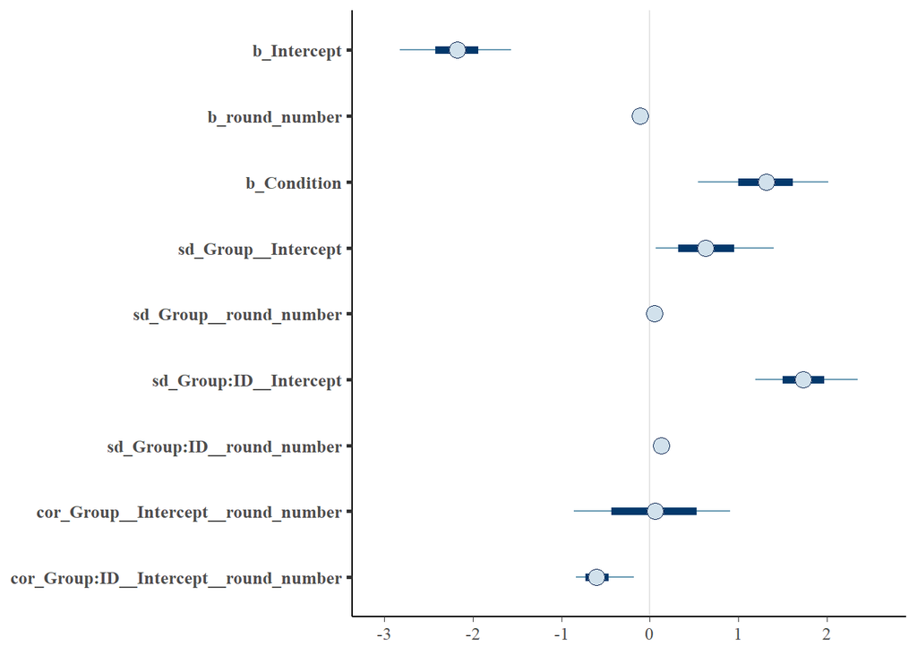

Trace plots to make sure Stan sampled efficiently.

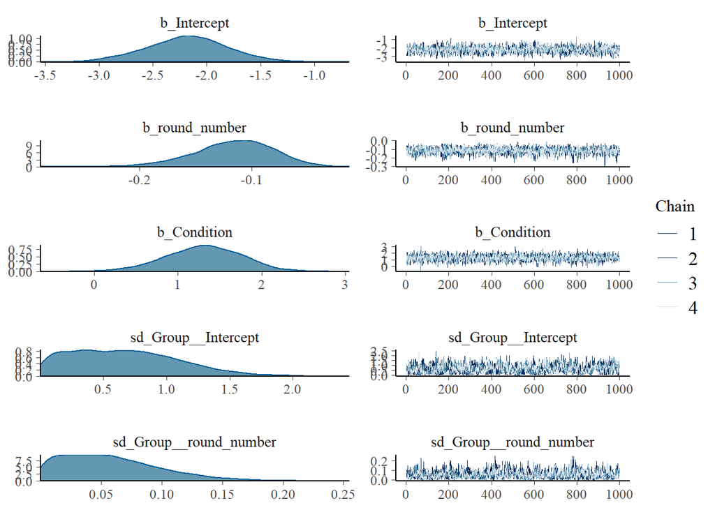

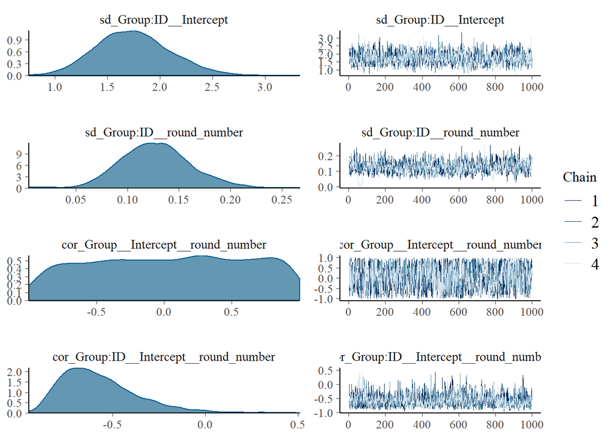

These HMC chains look healthy.

In this model, the fixed effect of condition was 1.30, with 95% credible intervals above 0. This implies that participants requested more in the Hidden condition. Again, we sample from the posterior and convert this to the probability scale.

```r
post <- readd(post1.04)

visible_prob <- inv_logit_scaled(post$b_Intercept)

visible_prob %>%
  median() %>%
  round(2)
```

```
## [1] 0.1
```

```r
hidden_prob  <- inv_logit_scaled(post$b_Intercept + post$b_Condition)

hidden_prob %>%
  median() %>%
  round(2)
```

```
## [1] 0.29
```

```r
difference   <- hidden_prob - visible_prob

quantile(difference,c(0.025,0.5,0.975)) %>% round(2)
```

```
##  2.5%   50% 97.5%
##  0.05  0.19  0.35
```

The probability difference between the conditions is +0.19 (median), with 95% CIs above 0. When above the minimum survival threshold (i.e. when they were not in need of help), participants were more likely to request from their partner in the Hidden condition.

Again, we compute a Bayes factor for this difference between probabilities.

```
## [1] 11.1
```

This Bayes factor implies strong support for the hypothesis that the probabilities differ across conditions.

# 5. Binomial - Probability of not responding to a request

Get long-format data frame with ‘received’ variable (i.e. how much a player received on any given round). We swap this around so it reflects how much the player *gave* to their partner (i.e. how much their partner received). We drop rows with NAs, since partners did not request help in that particular round. We then code whether the player gave nothing in response to the request (1) or gave at least one cattle (0).

| ID | Group | Condition | round_number | responded | notResponded |
| --- | --- | --- | --- | --- | --- |
| 1 | 1 | 1 | 1 | 0 | 1 |
| 3 | 2 | 1 | 1 | 0 | 1 |
| 5 | 3 | 1 | 1 | 1 | 0 |
| 6 | 3 | 1 | 1 | 1 | 0 |
| 7 | 4 | 1 | 1 | 0 | 1 |
| 8 | 4 | 1 | 1 | 10 | 0 |
| 9 | 5 | 1 | 1 | 2 | 0 |
| 15 | 8 | 1 | 1 | 0 | 1 |
| 18 | 9 | 1 | 1 | 4 | 0 |
| 19 | 10 | 1 | 1 | 0 | 1 |

[output cut: 278 more lines]

This leaves us with 288 possible responses to requests.

We then fit the varying intercept and slope model, again with participants nested within groups.

```
## function(d1.05) {
##   brm(data = d1.05, family = bernoulli,
##       notResponded ~ 0 + Intercept + round_number + Condition
##       + (0 + Intercept + round_number | Group/ID),
##       prior = c(prior(normal(0, 1), class = b),
##                 prior(student_t(3, 0, 10), class = sd),
##                 prior(lkj(1), class = cor)),
##       sample_prior = TRUE,
##       iter = 2500, warmup = 1000, chains = 4, cores = 4,
##       control = list(adapt_delta = 0.99),
##       seed = 2113)
## }
```

Here are the priors for the model we just fitted.

| prior | class | coef | group | resp | dpar | nlpar | bound |
| --- | --- | --- | --- | --- | --- | --- | --- |
| lkj_corr_cholesky(1) | L |  |  |  |  |  |  |
|  | L |  | Group |  |  |  |  |
|  | L |  | Group:ID |  |  |  |  |
| normal(0, 1) | b |  |  |  |  |  |  |
|  | b | Condition |  |  |  |  |  |
|  | b | Intercept |  |  |  |  |  |
|  | b | round_number |  |  |  |  |  |
| student_t(3, 0, 10) | sd |  |  |  |  |  |  |
|  | sd |  | Group |  |  |  |  |
|  | sd | Intercept | Group |  |  |  |  |

[output cut: 4 more lines]

The results.

```
##  Family: bernoulli
##   Links: mu = logit
## Formula: notResponded ~ 0 + Intercept + round_number + Condition + (0 + Intercept + round_number | Group/ID)
##    Data: d1.05 (Number of observations: 288)
## Samples: 4 chains, each with iter = 2500; warmup = 1000; thin = 1;
##          total post-warmup samples = 6000
##
## Group-Level Effects:
## ~Group (Number of levels: 41)
##                             Estimate Est.Error l-95% CI u-95% CI Rhat Bulk_ESS Tail_ESS
## sd(Intercept)                   1.18      0.81     0.05     3.03 1.01      805     1403
## sd(round_number)                0.52      0.25     0.15     1.11 1.01      580     1165
## cor(Intercept,round_number)     0.11      0.49    -0.84     0.94 1.02      346      456
##
## ~Group:ID (Number of levels: 71)
##                             Estimate Est.Error l-95% CI u-95% CI Rhat Bulk_ESS Tail_ESS
## sd(Intercept)                   0.67      0.51     0.04     1.91 1.00     2569     3689
## sd(round_number)                0.14      0.11     0.01     0.42 1.00     1447     2532
## cor(Intercept,round_number)    -0.24      0.56    -0.98     0.91 1.00     2225     3792
##
## Population-Level Effects:
##              Estimate Est.Error l-95% CI u-95% CI Rhat Bulk_ESS Tail_ESS
## Intercept       -1.23      0.56    -2.36    -0.16 1.00     4522     4195
## round_number    -0.26      0.16    -0.64    -0.02 1.00     1292     2604
## Condition        1.12      0.63    -0.11     2.32 1.00     5571     4235
##
## Samples were drawn using sampling(NUTS). For each parameter, Bulk_ESS
## and Tail_ESS are effective sample size measures, and Rhat is the potential
## scale reduction factor on split chains (at convergence, Rhat = 1).
```

Plotting the parameters.

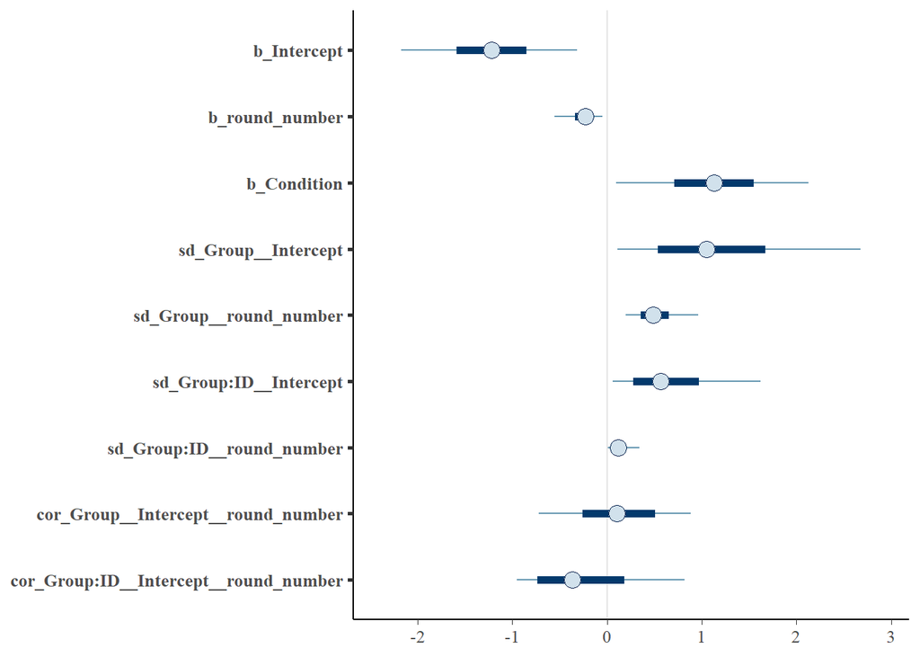

Let’s look at the trace plots to make sure Stan sampled efficiently.

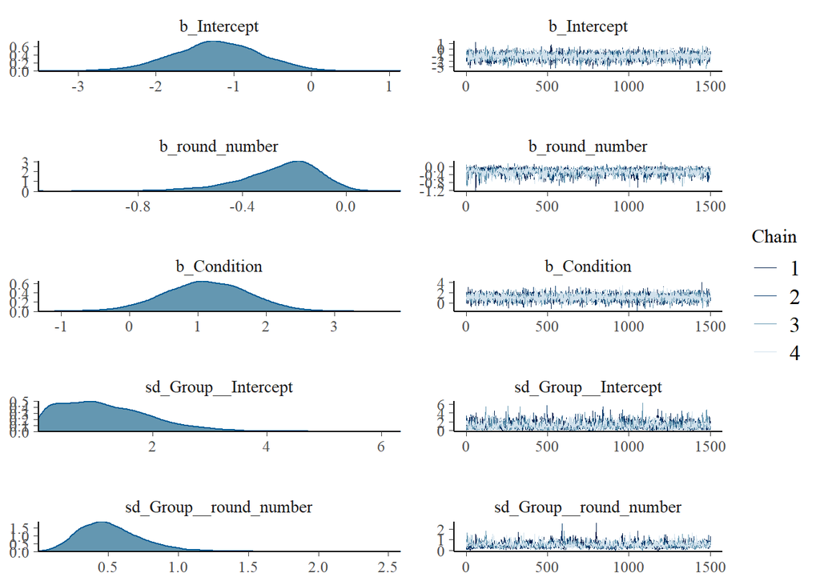

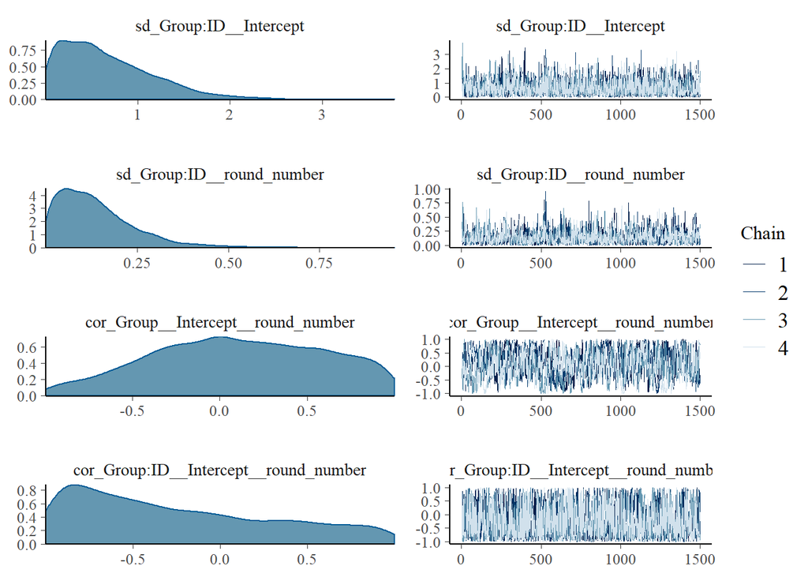

Despite the smaller sample size for this analysis, the RHat values, n_eff values, and trace plots look okay.

The fixed effect of condition is 1.12, with 95% credible intervals that cross 0. This implies that participants were only slightly less likely to respond to requests in the Hidden condition.

As before, we sample from the posterior and convert this difference to the absolute probability scale.

```r
post <- readd(post1.05)

visible_prob <- inv_logit_scaled(post$b_Intercept)

visible_prob %>%
  median() %>%
  round(2)
```

```
## [1] 0.23
```

```r
hidden_prob  <- inv_logit_scaled(post$b_Intercept + post$b_Condition)

hidden_prob %>%
  median() %>%
  round(2)
```

```
## [1] 0.48
```

```r
difference <- hidden_prob - visible_prob

quantile(difference,c(0.025,0.5,0.975)) %>% round(2)
```

```
##  2.5%   50% 97.5%
## -0.02  0.24  0.48
```

The probability difference between the conditions is 0.24 (median), with 95% CIs crossing 0. What’s the Bayes factor for this difference between probabilities?

```
## [1] 3.35
```

This Bayes factor implies moderate support for the hypothesis that the probabilities differ across conditions.

# 6. Binomial - Probability of not fulfilling a request when able

The data wrangling for this model is a little trickier.

1. First, we get a long-format data frame with (a) the player’s herd size that round, (b) how much the player received that round, and (c) how much the player requested that round.
2. Next, we flip the latter two variables to get (b’) how much the *player gave*, and (c’) how much the *player’s partner requested*. ‘Flipping’ is possible because partners sit next to the focal player in the data frame.
3. We drop rows with NAs, as no requesting happened this round.
4. We keep only rows in which the partner’s request could be fulfilled without dropping the player below the minimum survival threshold (i.e. the player was *able* to give).
5. Finally, we code whether the player fulfilled the request by giving what was asked or more (0) or did not fulfill the request (1).

| ID | Group | Condition | round_number | herd_size_after_shock | gave | partner_requested | notFulfilled |
| --- | --- | --- | --- | --- | --- | --- | --- |
| 1 | 1 | 1 | 1 | 73 | 0 | 6 | 1 |
| 3 | 2 | 1 | 1 | 72 | 0 | 1 | 1 |
| 5 | 3 | 1 | 1 | 68 | 1 | 2 | 1 |
| 6 | 3 | 1 | 1 | 74 | 1 | 6 | 1 |
| 9 | 5 | 1 | 1 | 69 | 2 | 2 | 0 |
| 21 | 11 | 1 | 1 | 75 | 4 | 10 | 1 |
| 24 | 12 | 1 | 1 | 74 | 0 | 10 | 1 |
| 34 | 17 | 1 | 1 | 69 | 3 | 3 | 0 |
| 37 | 19 | 1 | 1 | 72 | 0 | 3 | 1 |
| 44 | 22 | 0 | 1 | 73 | 0 | 1 | 1 |

[output cut: 223 more lines]

This leaves us with 233 possible response decisions in which the player was able to give their partner what they asked for. Our outcome variable is whether they fulfilled that request or not.

We now fit the varying intercept and slope model, again with participants nested within groups.

```
## function(d1.06) {
##   brm(data = d1.06, family = bernoulli,
##       notFulfilled ~ 0 + Intercept + round_number + Condition
##       + (0 + Intercept + round_number | Group/ID),
##       prior = c(prior(normal(0, 1), class = b),
##                 prior(student_t(3, 0, 10), class = sd),
##                 prior(lkj(1), class = cor)),
##       control = list(adapt_delta = 0.99),
##       sample_prior = TRUE,
##       iter = 2500, warmup = 1000, chains = 4, cores = 4,
##       seed = 2113)
## }
```

Here are the priors we used for model `m1.06`.

| prior | class | coef | group | resp | dpar | nlpar | bound |
| --- | --- | --- | --- | --- | --- | --- | --- |
| lkj_corr_cholesky(1) | L |  |  |  |  |  |  |
|  | L |  | Group |  |  |  |  |
|  | L |  | Group:ID |  |  |  |  |
| normal(0, 1) | b |  |  |  |  |  |  |
|  | b | Condition |  |  |  |  |  |
|  | b | Intercept |  |  |  |  |  |
|  | b | round_number |  |  |  |  |  |
| student_t(3, 0, 10) | sd |  |  |  |  |  |  |
|  | sd |  | Group |  |  |  |  |
|  | sd | Intercept | Group |  |  |  |  |

[output cut: 4 more lines]

Let’s see the results.

```
##  Family: bernoulli
##   Links: mu = logit
## Formula: notFulfilled ~ 0 + Intercept + round_number + Condition + (0 + Intercept + round_number | Group/ID)
##    Data: d1.06 (Number of observations: 233)
## Samples: 4 chains, each with iter = 2500; warmup = 1000; thin = 1;
##          total post-warmup samples = 6000
##
## Group-Level Effects:
## ~Group (Number of levels: 40)
##                             Estimate Est.Error l-95% CI u-95% CI Rhat Bulk_ESS Tail_ESS
## sd(Intercept)                   3.41      1.54     0.80     7.05 1.00     1187     1182
## sd(round_number)                0.33      0.16     0.08     0.72 1.00      768      795
## cor(Intercept,round_number)    -0.29      0.40    -0.87     0.64 1.00     1158     1275
##
## ~Group:ID (Number of levels: 61)
##                             Estimate Est.Error l-95% CI u-95% CI Rhat Bulk_ESS Tail_ESS
## sd(Intercept)                   1.18      1.04     0.04     3.90 1.00      859     1540
## sd(round_number)                0.09      0.09     0.00     0.33 1.00      981     1458
## cor(Intercept,round_number)    -0.34      0.57    -0.99     0.90 1.00     1750     3046
##
## Population-Level Effects:
##              Estimate Est.Error l-95% CI u-95% CI Rhat Bulk_ESS Tail_ESS
## Intercept       -0.03      0.66    -1.32     1.28 1.00     3641     4295
## round_number    -0.10      0.09    -0.32     0.06 1.00     2542     2581
## Condition        1.22      0.79    -0.34     2.76 1.00     3734     4065
##
## Samples were drawn using sampling(NUTS). For each parameter, Bulk_ESS
## and Tail_ESS are effective sample size measures, and Rhat is the potential
## scale reduction factor on split chains (at convergence, Rhat = 1).
```

Plotting the parameters.

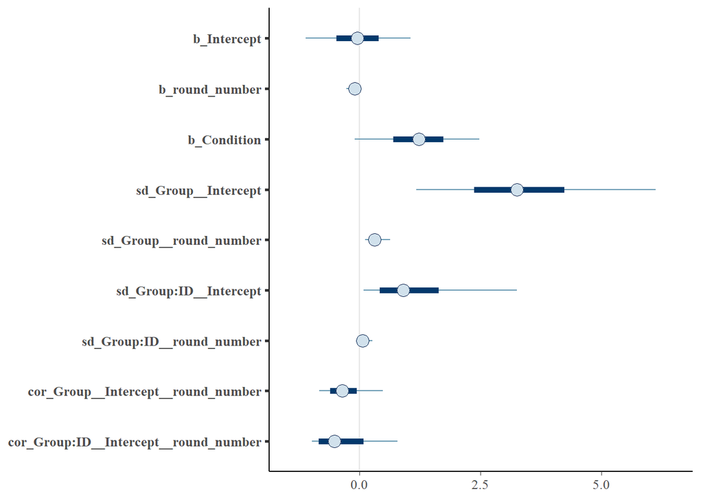

Let’s look at the trace plots to make sure Stan sampled efficiently.

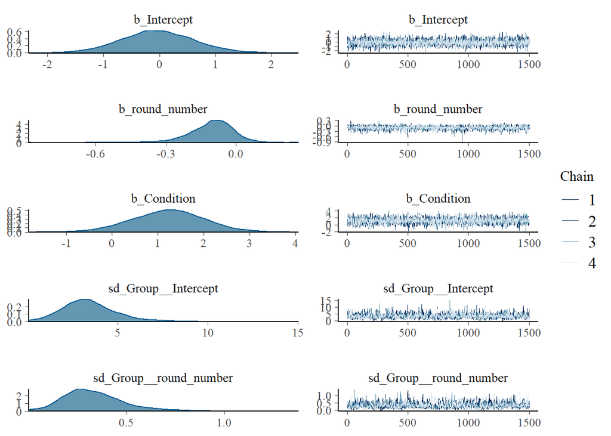

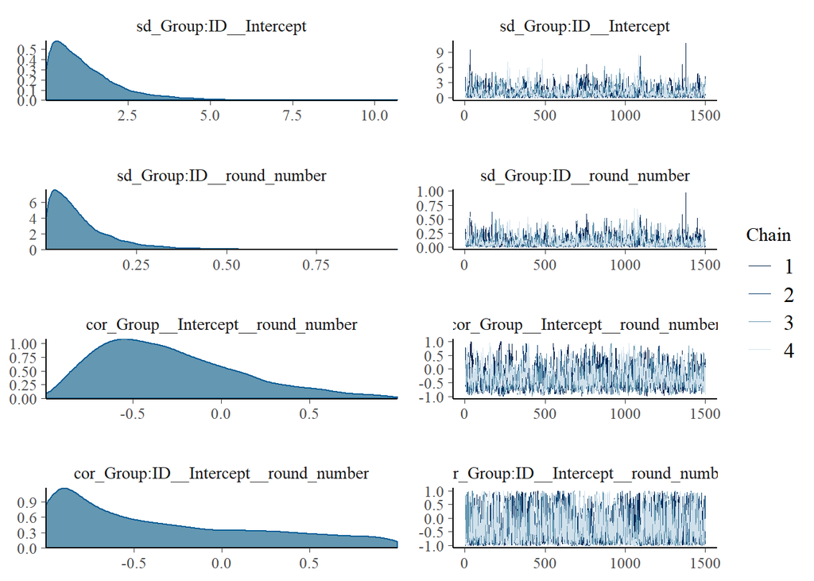

Again, the RHat values, n_eff values, and trace plots look okay.

The fixed effect of condition is 1.22, with 95% credible intervals crossing 0. This implies that participants fulfilled requests (when able) only slightly less in the Hidden condition.

Let’s get a sense of this on the absolute probability scale.

```r
post <- readd(post1.06)

visible_prob <- inv_logit_scaled(post$b_Intercept)

visible_prob %>%
  median() %>%
  round(2)
```

```
## [1] 0.49
```

```r
hidden_prob  <- inv_logit_scaled(post$b_Intercept + post$b_Condition)

hidden_prob %>%
  median() %>%
  round(2)
```

```
## [1] 0.76
```

```r
difference   <- hidden_prob - visible_prob

quantile(difference,c(0.025,0.5,0.975)) %>% round(2)
```

```
##  2.5%   50% 97.5%
## -0.08  0.25  0.54
```

The Bayes factor for this difference.

```
## [1] 3.03
```

This Bayes factor implies moderate support for the hypothesis that the probabilities differ across conditions.

# 7. Survival analysis - Condition

Get the data, adding a column for `censored`.

| ID | Group | Condition | rounds_survived | censored |
| --- | --- | --- | --- | --- |
| 1 | 1 | 1 | 25 | 1 |
| 2 | 1 | 1 | 11 | 0 |
| 3 | 2 | 1 | 25 | 1 |
| 4 | 2 | 1 | 19 | 0 |
| 5 | 3 | 1 | 25 | 1 |
| 6 | 3 | 1 | 25 | 1 |
| 7 | 4 | 1 | 25 | 1 |
| 8 | 4 | 1 | 3 | 0 |
| 9 | 5 | 1 | 25 | 1 |
| 10 | 5 | 1 | 25 | 1 |

[output cut: 72 more lines]

Fit the survival model.

```
## function(d1.07) {
##   # one participant per row so do not need the ID random effect
##   brm(rounds_survived | cens(censored) ~ 0 + Intercept + Condition + (1 | Group),
##       data = d1.07, family = weibull, inits = "0",
##       prior = prior(normal(0, 2), class = b, coef = "Condition"),
##       iter = 2000, warmup = 1000, chains = 4, cores = 4,
##       sample_prior = TRUE, seed = 2113)
## }
```

What priors did we use?

| prior | class | coef | group | resp | dpar | nlpar | bound |
| --- | --- | --- | --- | --- | --- | --- | --- |
|  | b |  |  |  |  |  |  |
| normal(0, 2) | b | Condition |  |  |  |  |  |
|  | b | Intercept |  |  |  |  |  |
| student_t(3, 0, 10) | sd |  |  |  |  |  |  |
|  | sd |  | Group |  |  |  |  |
|  | sd | Intercept | Group |  |  |  |  |
| gamma(0.01, 0.01) | shape |  |  |  |  |  |  |

Get the results.

```
##  Family: weibull
##   Links: mu = log; shape = identity
## Formula: rounds_survived | cens(censored) ~ 0 + Intercept + Condition + (1 | Group)
##    Data: d1.07 (Number of observations: 82)
## Samples: 4 chains, each with iter = 2000; warmup = 1000; thin = 1;
##          total post-warmup samples = 4000
##
## Group-Level Effects:
## ~Group (Number of levels: 41)
##               Estimate Est.Error l-95% CI u-95% CI Rhat Bulk_ESS Tail_ESS
## sd(Intercept)     1.06      0.29     0.59     1.72 1.00     1044     1661
##
## Population-Level Effects:
##           Estimate Est.Error l-95% CI u-95% CI Rhat Bulk_ESS Tail_ESS
## Intercept     3.60      0.35     3.00     4.39 1.00     1289     1264
## Condition     0.60      0.45    -0.28     1.51 1.00     1481     1802
##
## Family Specific Parameters:
##       Estimate Est.Error l-95% CI u-95% CI Rhat Bulk_ESS Tail_ESS
## shape     1.69      0.34     1.11     2.40 1.00     1833     2636
##
## Samples were drawn using sampling(NUTS). For each parameter, Bulk_ESS
## and Tail_ESS are effective sample size measures, and Rhat is the potential
## scale reduction factor on split chains (at convergence, Rhat = 1).
```

Plot the parameters.

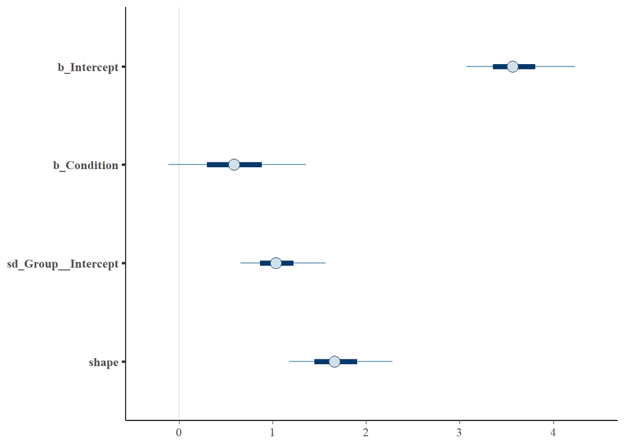

Trace plots.

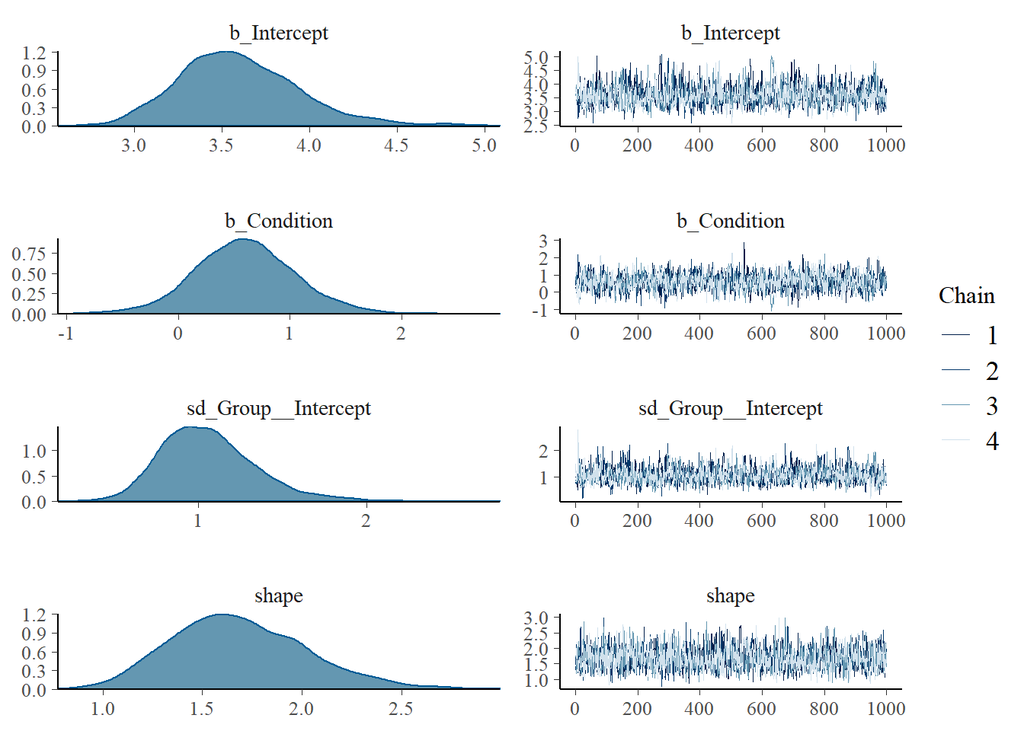

Conditional effects.

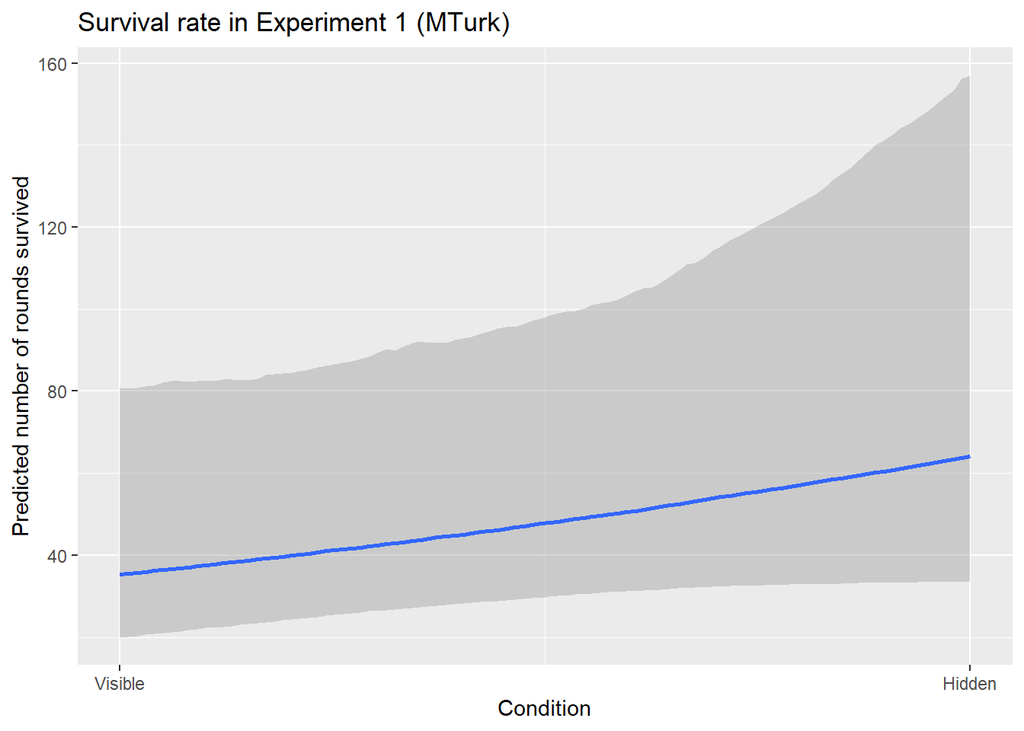

Estimate survival rate in the Visible condition.

```r
post <- readd(post1.07)

set.seed(2113)
srateVisible <- rweibull(4000, post$shape, exp(post$b_Intercept))
median(srateVisible)
```

```
## [1] 27.10621
```

Estimate survival rate in the Hidden condition.

```r
set.seed(2113)
srateHidden <- rweibull(4000, post$shape, exp(post$b_Intercept + post$b_Condition))
median(srateHidden)
```

```
## [1] 49.8679
```

Difference between these.

```r
difference <- srateHidden - srateVisible
quantile(difference, c(0.025, 0.5, 0.975)) %>% round(2)
```

```
##   2.5%    50%  97.5%
## -10.89  19.24 138.26
```

# 8. Survival analysis - Proportion of Rule 1 cheating

Get data.

| ID | Group | Condition | rounds_survived | censored | prop_rule1 |
| --- | --- | --- | --- | --- | --- |
| 1 | 1 | 1 | 25 | 1 | 0.00000000 |
| 2 | 1 | 1 | 11 | 0 | 0.66666667 |
| 3 | 2 | 1 | 25 | 1 | 0.15789474 |
| 4 | 2 | 1 | 19 | 0 | 0.21428571 |
| 5 | 3 | 1 | 25 | 1 | 0.20833333 |
| 6 | 3 | 1 | 25 | 1 | 0.12000000 |
| 7 | 4 | 1 | 25 | 1 | 1.00000000 |
| 9 | 5 | 1 | 25 | 1 | 0.17391304 |
| 10 | 5 | 1 | 25 | 1 | 0.44000000 |
| 11 | 6 | 1 | 25 | 1 | 0.16000000 |

[output cut: 70 more lines]

Fit the model.

```
## function(d1.08) {
##   brm(rounds_survived | cens(censored) ~ 0 + Intercept + prop_rule1 + (1 | Group),
##       data = d1.08, family = weibull, inits = "0",
##       prior = prior(normal(0, 2), class = b, coef = "prop_rule1"),
##       iter = 2000, warmup = 1000, chains = 4, cores = 4,
##       sample_prior = TRUE, seed = 2113)
## }
```

Priors.

| prior | class | coef | group | resp | dpar | nlpar | bound |
| --- | --- | --- | --- | --- | --- | --- | --- |
|  | b |  |  |  |  |  |  |
|  | b | Intercept |  |  |  |  |  |
| normal(0, 2) | b | prop_rule1 |  |  |  |  |  |
| student_t(3, 0, 10) | sd |  |  |  |  |  |  |
|  | sd |  | Group |  |  |  |  |
|  | sd | Intercept | Group |  |  |  |  |
| gamma(0.01, 0.01) | shape |  |  |  |  |  |  |

Print results.

```
##  Family: weibull
##   Links: mu = log; shape = identity
## Formula: rounds_survived | cens(censored) ~ 0 + Intercept + prop_rule1 + (1 | Group)
##    Data: d1.08 (Number of observations: 80)
## Samples: 4 chains, each with iter = 2000; warmup = 1000; thin = 1;
##          total post-warmup samples = 4000
##
## Group-Level Effects:
## ~Group (Number of levels: 41)
##               Estimate Est.Error l-95% CI u-95% CI Rhat Bulk_ESS Tail_ESS
## sd(Intercept)     1.09      0.27     0.66     1.71 1.00     1264     1835
##
## Population-Level Effects:
##            Estimate Est.Error l-95% CI u-95% CI Rhat Bulk_ESS Tail_ESS
## Intercept      3.97      0.31     3.45     4.66 1.00     2215     2562
## prop_rule1    -0.87      0.51    -1.91     0.08 1.00     2770     2783
##
## Family Specific Parameters:
##       Estimate Est.Error l-95% CI u-95% CI Rhat Bulk_ESS Tail_ESS
## shape     2.35      0.49     1.48     3.38 1.00     1883     1943
##
## Samples were drawn using sampling(NUTS). For each parameter, Bulk_ESS
## and Tail_ESS are effective sample size measures, and Rhat is the potential
## scale reduction factor on split chains (at convergence, Rhat = 1).
```

Plot parameters.

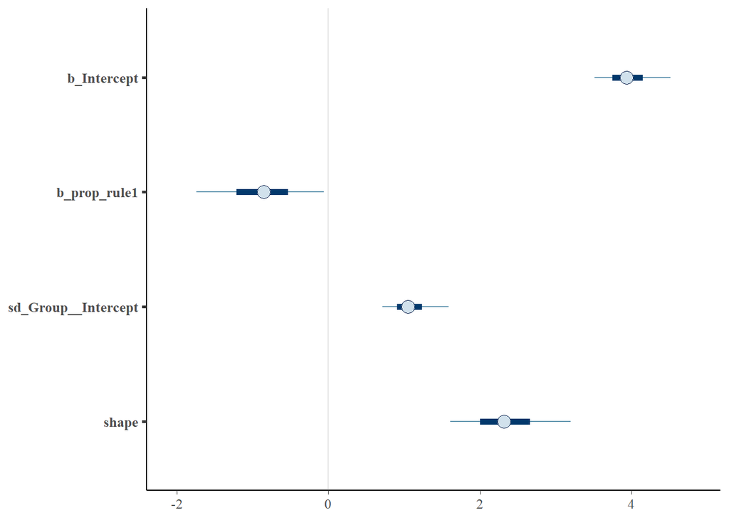

Trace plots.

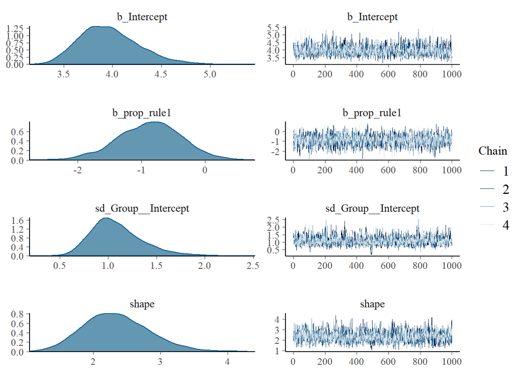

Conditional effects.

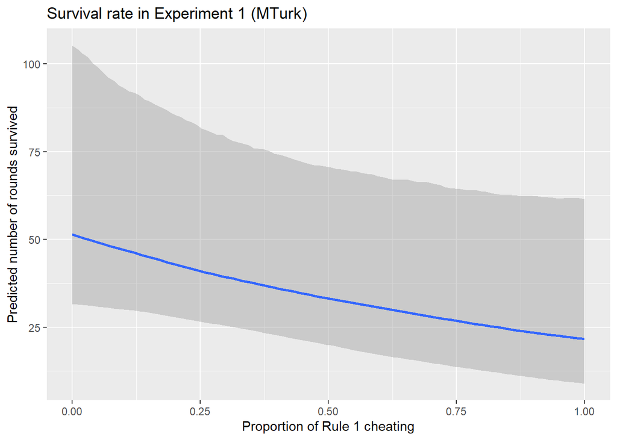

# 9. Survival analysis - Proportion of Rule 2 cheating

Get data.

| ID | Group | Condition | rounds_survived | censored | prop_rule2 |
| --- | --- | --- | --- | --- | --- |
| 1 | 1 | 1 | 25 | 1 | 1.0000000 |
| 3 | 2 | 1 | 25 | 1 | 0.5714286 |
| 4 | 2 | 1 | 19 | 0 | 0.0000000 |
| 5 | 3 | 1 | 25 | 1 | 0.5000000 |
| 6 | 3 | 1 | 25 | 1 | 1.0000000 |
| 7 | 4 | 1 | 25 | 1 | 1.0000000 |
| 9 | 5 | 1 | 25 | 1 | 0.6363636 |
| 10 | 5 | 1 | 25 | 1 | 0.6666667 |
| 11 | 6 | 1 | 25 | 1 | 0.3333333 |
| 12 | 6 | 1 | 25 | 1 | 0.5000000 |

[output cut: 51 more lines]

Fit the model.

```
## function(d1.09) {
##   brm(rounds_survived | cens(censored) ~ 0 + Intercept + prop_rule2 + (1 | Group),
##       data = d1.09, family = weibull, inits = "0",
##       prior = prior(normal(0, 2), class = b, coef = "prop_rule2"),
##       iter = 4000, warmup = 2000, chains = 4, cores = 4,
##       control = list(adapt_delta = 0.99),
##       sample_prior = TRUE, seed = 2113)
## }
```

Priors.

| prior | class | coef | group | resp | dpar | nlpar | bound |
| --- | --- | --- | --- | --- | --- | --- | --- |
|  | b |  |  |  |  |  |  |
|  | b | Intercept |  |  |  |  |  |
| normal(0, 2) | b | prop_rule2 |  |  |  |  |  |
| student_t(3, 0, 10) | sd |  |  |  |  |  |  |
|  | sd |  | Group |  |  |  |  |
|  | sd | Intercept | Group |  |  |  |  |
| gamma(0.01, 0.01) | shape |  |  |  |  |  |  |

Print results.

```
##  Family: weibull
##   Links: mu = log; shape = identity
## Formula: rounds_survived | cens(censored) ~ 0 + Intercept + prop_rule2 + (1 | Group)
##    Data: d1.09 (Number of observations: 61)
## Samples: 4 chains, each with iter = 4000; warmup = 2000; thin = 1;
##          total post-warmup samples = 8000
##
## Group-Level Effects:
## ~Group (Number of levels: 40)
##               Estimate Est.Error l-95% CI u-95% CI Rhat Bulk_ESS Tail_ESS
## sd(Intercept)     1.34      0.49     0.40     2.45 1.01      675      518
##
## Population-Level Effects:
##            Estimate Est.Error l-95% CI u-95% CI Rhat Bulk_ESS Tail_ESS
## Intercept      4.07      0.52     3.26     5.32 1.00     2970     3463
## prop_rule2     0.48      0.57    -0.60     1.67 1.00     3852     4518
##
## Family Specific Parameters:
##       Estimate Est.Error l-95% CI u-95% CI Rhat Bulk_ESS Tail_ESS
## shape     2.34      0.90     1.02     4.43 1.01      874     2239
##
## Samples were drawn using sampling(NUTS). For each parameter, Bulk_ESS
## and Tail_ESS are effective sample size measures, and Rhat is the potential
## scale reduction factor on split chains (at convergence, Rhat = 1).
```

Plot parameters.

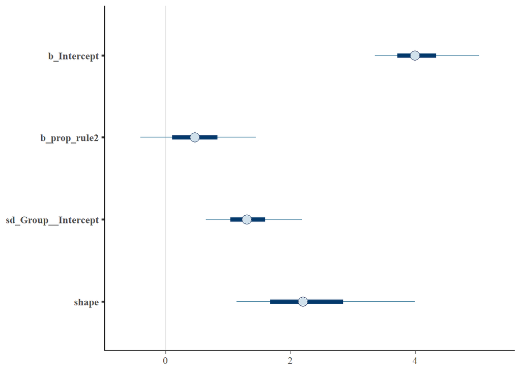

Trace plots.

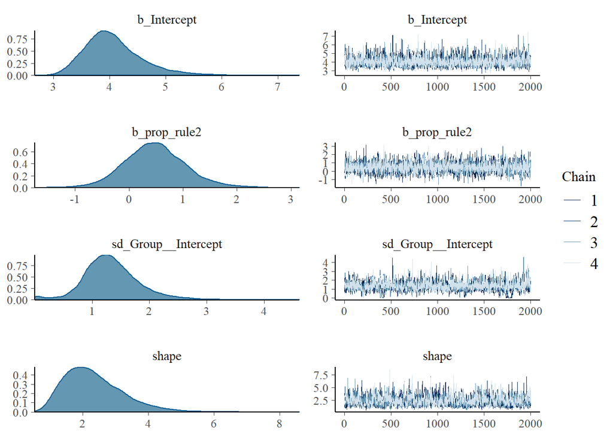

Conditional effects.

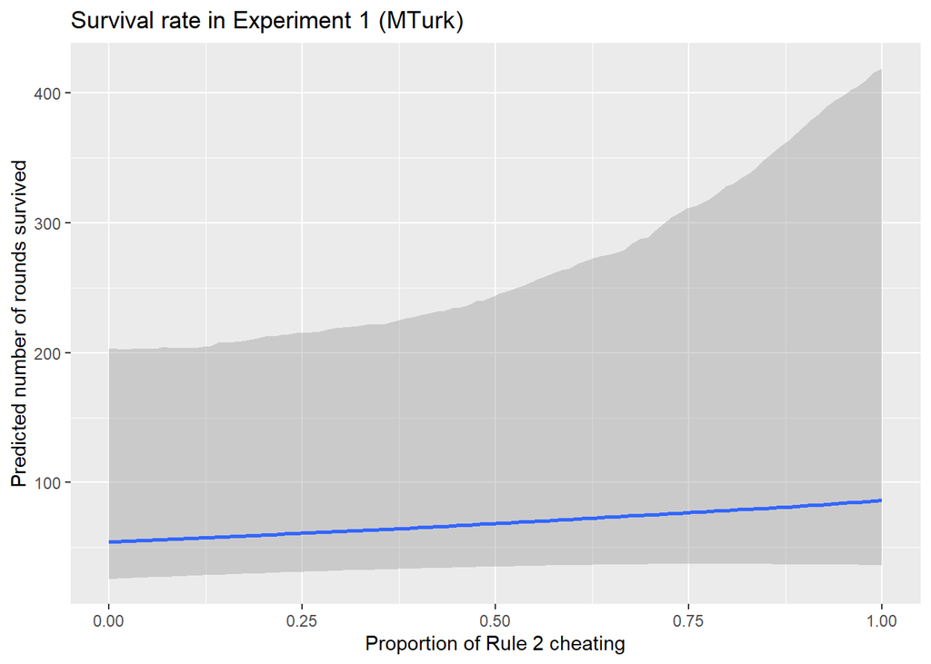

# 10. Herd size when requesting / not requesting

Get data.

| ID | Group | Condition | round_number | herd_size_after_shock | request |
| --- | --- | --- | --- | --- | --- |
| 1 | 1 | 1 | 1 | 73 | 0 |
| 2 | 1 | 1 | 1 | 72 | 1 |
| 3 | 2 | 1 | 1 | 72 | 0 |
| 4 | 2 | 1 | 1 | 63 | 1 |
| 5 | 3 | 1 | 1 | 68 | 1 |
| 6 | 3 | 1 | 1 | 74 | 1 |
| 7 | 4 | 1 | 1 | 68 | 1 |
| 8 | 4 | 1 | 1 | 59 | 1 |
| 9 | 5 | 1 | 1 | 69 | 0 |
| 10 | 5 | 1 | 1 | 71 | 1 |

[output cut: 990 more lines]

Fit model.

```
## function(d1.10) {
##   brm(herd_size_after_shock ~ 0 + Intercept + round_number + Condition*request +
##         (1 + round_number | Group/ID),
##       data = d1.10,
##       prior = c(prior(normal(0, 100), class = b, coef = 'Intercept'),
##                 prior(normal(0, 5), class = b, coef = 'round_number'),
##                 prior(normal(0, 5), class = b, coef = 'Condition'),
##                 prior(normal(0, 5), class = b, coef = 'request'),
##                 prior(normal(0, 5), class = b, coef = 'Condition:request')),
##       iter = 4000, warmup = 2000, chains = 4, cores = 4,
##       control = list(adapt_delta = 0.95),
##       sample_prior = TRUE, seed = 2113)
## }
```

Priors.

| prior | class | coef | group | resp | dpar | nlpar | bound |
| --- | --- | --- | --- | --- | --- | --- | --- |
|  | b |  |  |  |  |  |  |
| normal(0, 5) | b | Condition |  |  |  |  |  |
| normal(0, 5) | b | Condition:request |  |  |  |  |  |
| normal(0, 100) | b | Intercept |  |  |  |  |  |
| normal(0, 5) | b | request |  |  |  |  |  |
| normal(0, 5) | b | round_number |  |  |  |  |  |
| lkj_corr_cholesky(1) | L |  |  |  |  |  |  |
|  | L |  | Group |  |  |  |  |
|  | L |  | Group:ID |  |  |  |  |
| student_t(3, 0, 12) | sd |  |  |  |  |  |  |

[output cut: 7 more lines]

Print results.

```
##  Family: gaussian
##   Links: mu = identity; sigma = identity
## Formula: herd_size_after_shock ~ 0 + Intercept + round_number + Condition * request + (1 + round_number | Group/ID)
##    Data: d1.10 (Number of observations: 1464)
## Samples: 4 chains, each with iter = 4000; warmup = 2000; thin = 1;
##          total post-warmup samples = 8000
##
## Group-Level Effects:
## ~Group (Number of levels: 41)
##                             Estimate Est.Error l-95% CI u-95% CI Rhat Bulk_ESS Tail_ESS
## sd(Intercept)                   2.73      1.43     0.16     5.44 1.01      769     1846
## sd(round_number)                0.78      0.27     0.17     1.29 1.00      894      982
## cor(Intercept,round_number)    -0.25      0.47    -0.94     0.84 1.00      736     1195
##
## ~Group:ID (Number of levels: 82)
##                             Estimate Est.Error l-95% CI u-95% CI Rhat Bulk_ESS Tail_ESS
## sd(Intercept)                   6.11      0.80     4.60     7.73 1.01     1305     3835
## sd(round_number)                1.08      0.15     0.82     1.39 1.00     1484     2967
## cor(Intercept,round_number)    -0.32      0.16    -0.61     0.03 1.00     1747     3630
##
## Population-Level Effects:
##                   Estimate Est.Error l-95% CI u-95% CI Rhat Bulk_ESS Tail_ESS
## Intercept            73.58      1.24    71.16    76.00 1.00     5270     6147
## round_number         -0.13      0.19    -0.52     0.23 1.00     6146     5326
## Condition             2.51      1.68    -0.84     5.76 1.00     5635     6025
## request              -7.81      0.75    -9.27    -6.33 1.00    13269     6412
## Condition:request     2.45      0.98     0.51     4.37 1.00    12803     6308
##
## Family Specific Parameters:
##       Estimate Est.Error l-95% CI u-95% CI Rhat Bulk_ESS Tail_ESS
## sigma     6.13      0.12     5.91     6.37 1.00    10343     5558
##
## Samples were drawn using sampling(NUTS). For each parameter, Bulk_ESS
## and Tail_ESS are effective sample size measures, and Rhat is the potential
## scale reduction factor on split chains (at convergence, Rhat = 1).
```

Trace plots.

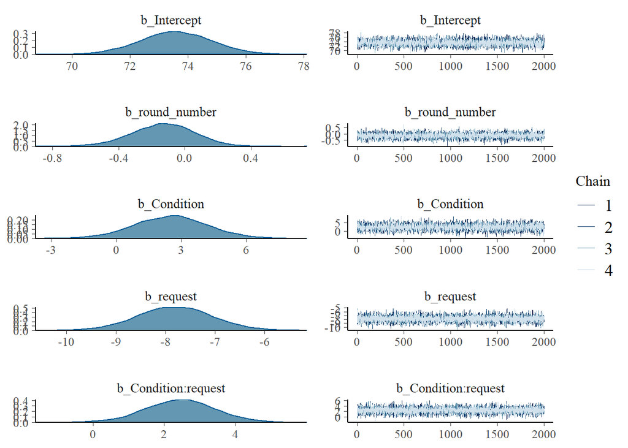

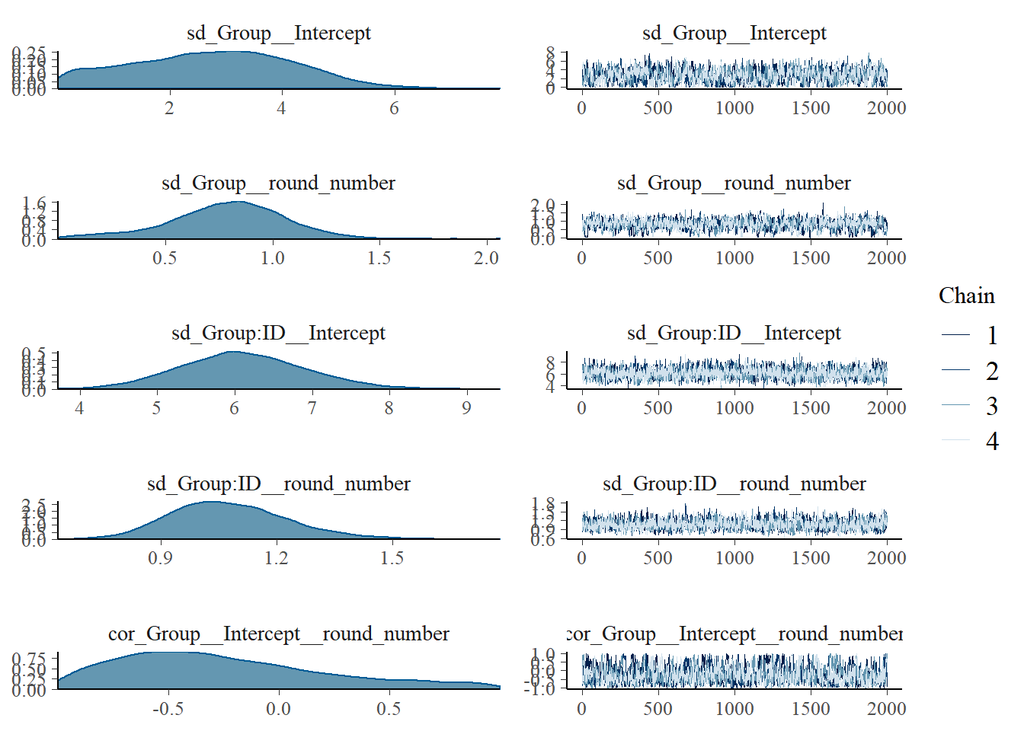

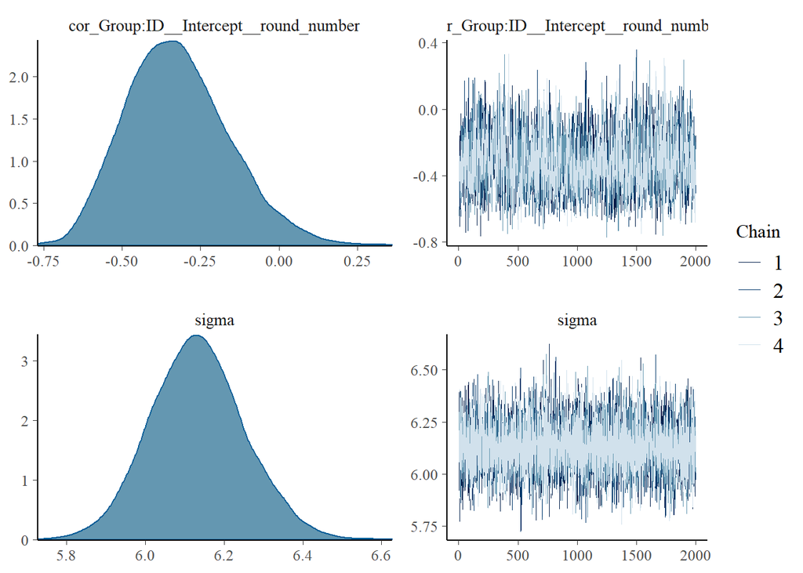

For participants in the Visible condition, posterior herd size when not requesting:

```
## [1] 73.57
```

And when requesting:

```
## [1] 65.78
```

For participants in the Hidden condition, posterior herd size when not requesting:

```
## [1] 76.1
```

And when requesting:

```
## [1] 70.73
```

Does the herd size when requesting differ across conditions? Get the posterior difference.

```
##  2.5%   50% 97.5%
##  1.38  4.98  8.54
```

Yes. Participants in the Hidden condition have more resources when they request from their partner than participants in the Visible condition.

# 11. Amount requested

Get data. We log the outcome as `request_amount` follows an exponential distribution.

| ID | Group | Condition | round_number | herd_size_after_shock | request_amount | request_amount.log |
| --- | --- | --- | --- | --- | --- | --- |
| 2 | 1 | 1 | 1 | 72 | 6 | 1.7917595 |
| 4 | 2 | 1 | 1 | 63 | 1 | 0.0000000 |
| 5 | 3 | 1 | 1 | 68 | 6 | 1.7917595 |
| 6 | 3 | 1 | 1 | 74 | 2 | 0.6931472 |
| 7 | 4 | 1 | 1 | 68 | 30 | 3.4011974 |
| 8 | 4 | 1 | 1 | 59 | 10 | 2.3025851 |
| 10 | 5 | 1 | 1 | 71 | 2 | 0.6931472 |
| 16 | 8 | 1 | 1 | 74 | 10 | 2.3025851 |
| 17 | 9 | 1 | 1 | 70 | 10 | 2.3025851 |
| 19 | 10 | 1 | 1 | 70 | 15 | 2.7080502 |

[output cut: 278 more lines]

Fit model.

```
## function(d1.11) {
##   brm(request_amount.log ~ 0 + Intercept + round_number + Condition +
##         (1 + round_number | Group/ID),
##       data = d1.11,
##       prior = c(prior(normal(0, 5), class = b, coef = 'Intercept'),
##                 prior(normal(0, 2), class = b, coef = 'round_number'),
##                 prior(normal(0, 2), class = b, coef = 'Condition')),
##       iter = 2000, warmup = 1000, chains = 4, cores = 4,
##       sample_prior = TRUE, seed = 2113)
## }
```

Priors.

| prior | class | coef | group | resp | dpar | nlpar | bound |
| --- | --- | --- | --- | --- | --- | --- | --- |
|  | b |  |  |  |  |  |  |
| normal(0, 2) | b | Condition |  |  |  |  |  |
| normal(0, 5) | b | Intercept |  |  |  |  |  |
| normal(0, 2) | b | round_number |  |  |  |  |  |
| lkj_corr_cholesky(1) | L |  |  |  |  |  |  |
|  | L |  | Group |  |  |  |  |
|  | L |  | Group:ID |  |  |  |  |
| student_t(3, 0, 10) | sd |  |  |  |  |  |  |
|  | sd |  | Group |  |  |  |  |
|  | sd | Intercept | Group |  |  |  |  |

[output cut: 5 more lines]

Print results.

```
##  Family: gaussian
##   Links: mu = identity; sigma = identity
## Formula: request_amount.log ~ 0 + Intercept + round_number + Condition + (1 + round_number | Group/ID)
##    Data: d1.11 (Number of observations: 288)
## Samples: 4 chains, each with iter = 2000; warmup = 1000; thin = 1;
##          total post-warmup samples = 4000
##
## Group-Level Effects:
## ~Group (Number of levels: 41)
##                             Estimate Est.Error l-95% CI u-95% CI Rhat Bulk_ESS Tail_ESS
## sd(Intercept)                   0.47      0.09     0.31     0.66 1.00     1616     2497
## sd(round_number)                0.01      0.01     0.00     0.03 1.01      923     1046
## cor(Intercept,round_number)    -0.06      0.54    -0.93     0.92 1.00     3158     2376
##
## ~Group:ID (Number of levels: 71)
##                             Estimate Est.Error l-95% CI u-95% CI Rhat Bulk_ESS Tail_ESS
## sd(Intercept)                   0.09      0.07     0.00     0.26 1.00     1338     1686
## sd(round_number)                0.01      0.01     0.00     0.02 1.01     1213     1651
## cor(Intercept,round_number)    -0.16      0.57    -0.96     0.92 1.00     1907     2546
##
## Population-Level Effects:
##              Estimate Est.Error l-95% CI u-95% CI Rhat Bulk_ESS Tail_ESS
## Intercept        1.03      0.14     0.76     1.31 1.00     1641     2449
## round_number     0.01      0.01    -0.00     0.03 1.00     4204     3209
## Condition        0.33      0.18    -0.02     0.69 1.01     1206     1891
##
## Family Specific Parameters:
##       Estimate Est.Error l-95% CI u-95% CI Rhat Bulk_ESS Tail_ESS
## sigma     0.64      0.03     0.58     0.69 1.00     4629     3218
##
## Samples were drawn using sampling(NUTS). For each parameter, Bulk_ESS
## and Tail_ESS are effective sample size measures, and Rhat is the potential
## scale reduction factor on split chains (at convergence, Rhat = 1).
```

Trace plots.

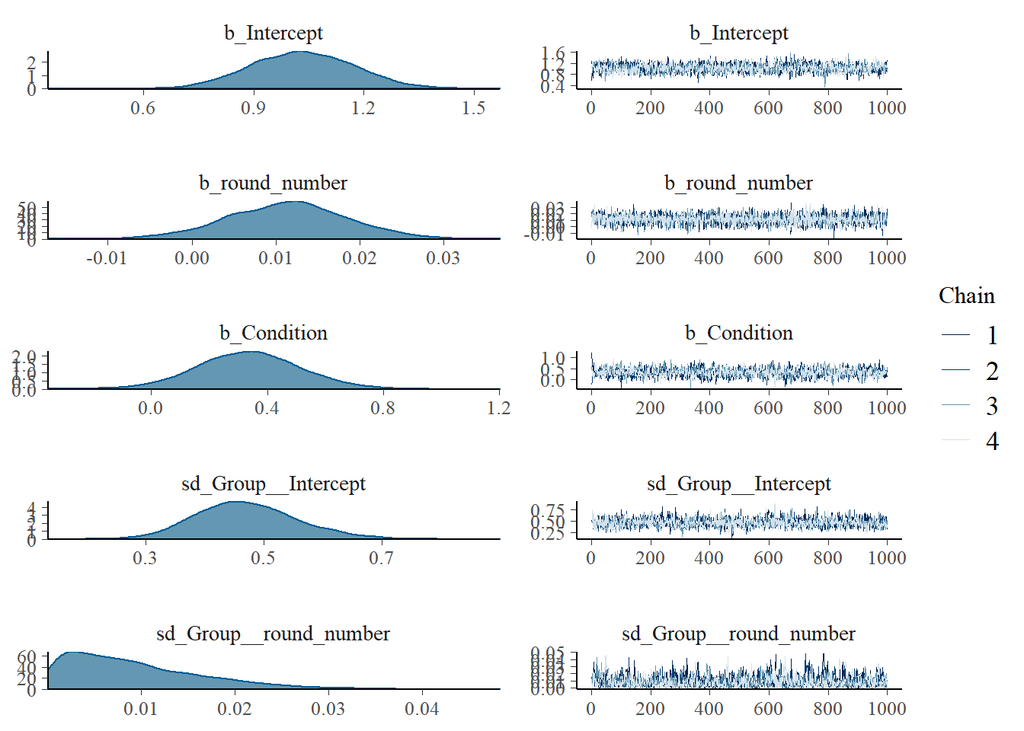

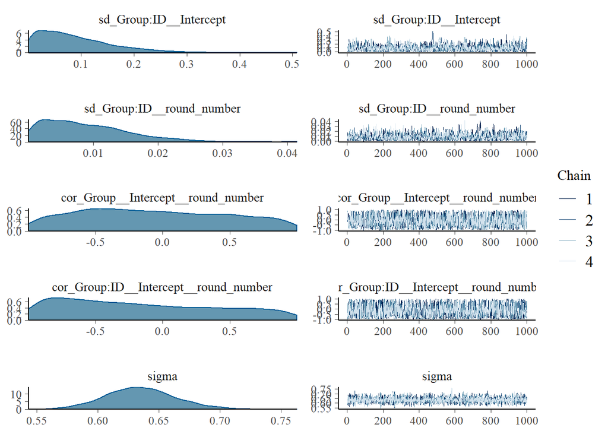

How many cattle are requested on average by participants in the Visible condition?

```
## [1] 2.81
```

And in the Hidden condition?

```
## [1] 3.92
```

Do these amounts differ?

```r
quantile(exp(post$b_Intercept) - exp(post$b_Intercept + post$b_Condition), c(.025, .5, .975)) %>% round(2)
```

```
##  2.5%   50% 97.5%
## -2.40 -1.12  0.07
```

Not quite.

# 12. Difference between amount requested and amount required

Get data. We focus only on requests made when beneath the threshold, and calculate the `diff` between the amount requested and the amount required to get to 64 (the minimum threshold).

| ID | Group | Condition | round_number | herd_size_after_shock | request_amount | diff |
| --- | --- | --- | --- | --- | --- | --- |
| 4 | 2 | 1 | 1 | 63 | 1 | 0 |
| 8 | 4 | 1 | 1 | 59 | 10 | 5 |
| 32 | 16 | 1 | 1 | 63 | 10 | 9 |
| 48 | 24 | 0 | 1 | 56 | 2 | -6 |
| 49 | 25 | 0 | 1 | 62 | 2 | 0 |
| 61 | 31 | 0 | 1 | 61 | 3 | 0 |
| 65 | 33 | 0 | 1 | 57 | 7 | 0 |
| 77 | 39 | 0 | 1 | 59 | 5 | 0 |
| 8 | 4 | 1 | 2 | 50 | 14 | 0 |
| 18 | 9 | 1 | 2 | 60 | 10 | 6 |

[output cut: 99 more lines]

Fit model.

```
## function(d1.12) {
##   brm(diff ~ 0 + Intercept + round_number + Condition +
##         (1 + round_number | Group/ID),
##       data = d1.12,
##       prior = c(prior(normal(0, 2), class = b, coef = 'Intercept'),
##                 prior(normal(0, 2), class = b, coef = 'round_number'),
##                 prior(normal(0, 2), class = b, coef = 'Condition')),
##       iter = 2000, warmup = 1000, chains = 4, cores = 4,
##       control = list(adapt_delta = 0.9),
##       sample_prior = TRUE, seed = 2113)
## }
```

Priors.

| prior | class | coef | group | resp | dpar | nlpar | bound |
| --- | --- | --- | --- | --- | --- | --- | --- |
|  | b |  |  |  |  |  |  |
| normal(0, 2) | b | Condition |  |  |  |  |  |
| normal(0, 2) | b | Intercept |  |  |  |  |  |
| normal(0, 2) | b | round_number |  |  |  |  |  |
| lkj_corr_cholesky(1) | L |  |  |  |  |  |  |
|  | L |  | Group |  |  |  |  |
|  | L |  | Group:ID |  |  |  |  |
| student_t(3, 0, 10) | sd |  |  |  |  |  |  |
|  | sd |  | Group |  |  |  |  |
|  | sd | Intercept | Group |  |  |  |  |

[output cut: 5 more lines]

Print results.

```
##  Family: gaussian
##   Links: mu = identity; sigma = identity
## Formula: diff ~ 0 + Intercept + round_number + Condition + (1 + round_number | Group/ID)
##    Data: d1.12 (Number of observations: 109)
## Samples: 4 chains, each with iter = 2000; warmup = 1000; thin = 1;
##          total post-warmup samples = 4000
##
## Group-Level Effects:
## ~Group (Number of levels: 35)
##                             Estimate Est.Error l-95% CI u-95% CI Rhat Bulk_ESS Tail_ESS
## sd(Intercept)                   1.52      0.79     0.12     3.08 1.00      869     1484
## sd(round_number)                0.08      0.06     0.00     0.21 1.00     1236     1943
## cor(Intercept,round_number)    -0.09      0.56    -0.94     0.93 1.00     2407     2810
##
## ~Group:ID (Number of levels: 49)
##                             Estimate Est.Error l-95% CI u-95% CI Rhat Bulk_ESS Tail_ESS
## sd(Intercept)                   1.30      0.76     0.07     2.89 1.00     1051     1842
## sd(round_number)                0.09      0.06     0.00     0.24 1.00     1060     2086
## cor(Intercept,round_number)    -0.19      0.56    -0.97     0.92 1.00     2323     2670
##
## Population-Level Effects:
##              Estimate Est.Error l-95% CI u-95% CI Rhat Bulk_ESS Tail_ESS
## Intercept       -0.31      0.74    -1.72     1.16 1.00     3403     2822
## round_number    -0.10      0.06    -0.22     0.03 1.00     3586     2849
## Condition        2.49      0.87     0.68     4.16 1.00     3968     2693
##
## Family Specific Parameters:
##       Estimate Est.Error l-95% CI u-95% CI Rhat Bulk_ESS Tail_ESS
## sigma     2.70      0.24     2.26     3.21 1.00     2112     3221
##
## Samples were drawn using sampling(NUTS). For each parameter, Bulk_ESS
## and Tail_ESS are effective sample size measures, and Rhat is the potential
## scale reduction factor on split chains (at convergence, Rhat = 1).
```

Trace plots.

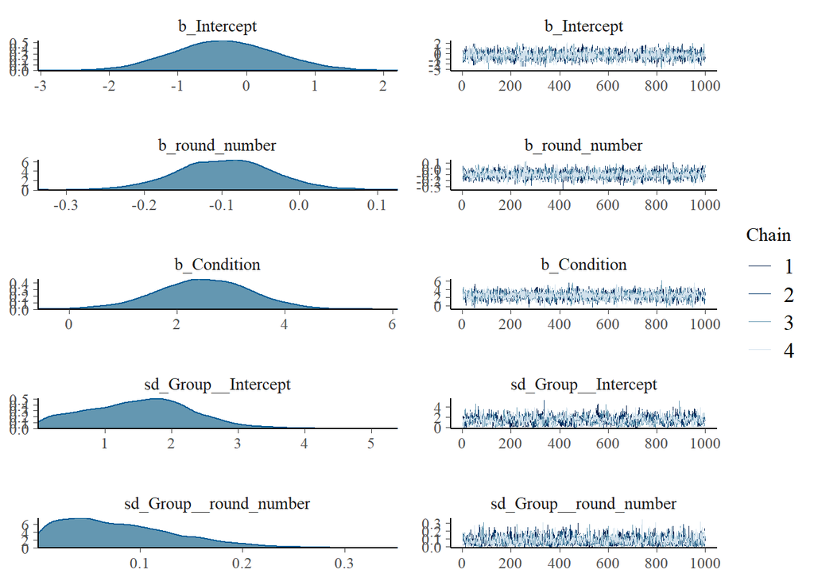

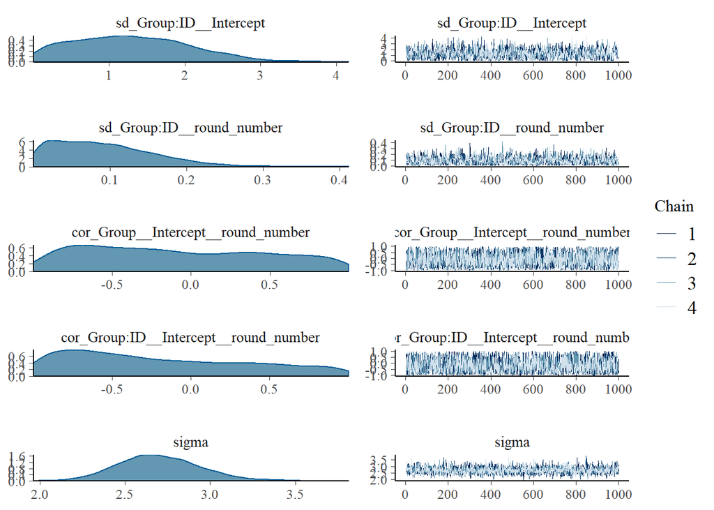

What’s the posterior `diff` score for participants in the Visible condition? A positive score indicates asking for “too many” resources, while a negative number indicates asking for “too few”.

```
##  2.5%   50% 97.5%
## -1.72 -0.33  1.16
```

And for participants in the Hidden condition?

```
##  2.5%   50% 97.5%
##  0.50  2.18  3.88
```

# 13. Difference between amount requested by partner and amount given

Get data. `diff` is the difference between amount requested by partner and amount given.

| ID | Group | Condition | round_number | gave | partner_requested | diff |
| --- | --- | --- | --- | --- | --- | --- |
| 1 | 1 | 1 | 1 | 0 | 6 | -6 |
| 3 | 2 | 1 | 1 | 0 | 1 | -1 |
| 5 | 3 | 1 | 1 | 1 | 2 | -1 |
| 6 | 3 | 1 | 1 | 1 | 6 | -5 |
| 7 | 4 | 1 | 1 | 0 | 10 | -10 |
| 8 | 4 | 1 | 1 | 10 | 30 | -20 |
| 9 | 5 | 1 | 1 | 2 | 2 | 0 |
| 15 | 8 | 1 | 1 | 0 | 10 | -10 |
| 18 | 9 | 1 | 1 | 4 | 10 | -6 |
| 19 | 10 | 1 | 1 | 0 | 28 | -28 |

[output cut: 278 more lines]

Fit model.

```
## function(d1.13) {
##   # deal with outliers by using student-t distribution
##   # https://solomonkurz.netlify.app/post/robust-linear-regression-with-the-robust-student-s-t-distribution/
##   brm(bf(diff ~ 0 + Intercept + round_number + Condition +
##         (1 + round_number | Group/ID), nu = 4),
##       data = d1.13, family = student,
##       prior = c(prior(normal(0, 5), class = b, coef = 'Intercept'),
##                 prior(normal(0, 2), class = b, coef = 'round_number'),
##                 prior(normal(0, 2), class = b, coef = 'Condition')),
##       iter = 4000, warmup = 2000, chains = 4, cores = 4,
##       control = list(adapt_delta = 0.95),
##       sample_prior = TRUE, seed = 2113)
## }
```

Priors.

| prior | class | coef | group | resp | dpar | nlpar | bound |
| --- | --- | --- | --- | --- | --- | --- | --- |
|  | b |  |  |  |  |  |  |
| normal(0, 2) | b | Condition |  |  |  |  |  |
| normal(0, 5) | b | Intercept |  |  |  |  |  |
| normal(0, 2) | b | round_number |  |  |  |  |  |
| lkj_corr_cholesky(1) | L |  |  |  |  |  |  |
|  | L |  | Group |  |  |  |  |
|  | L |  | Group:ID |  |  |  |  |
| student_t(3, 0, 10) | sd |  |  |  |  |  |  |
|  | sd |  | Group |  |  |  |  |
|  | sd | Intercept | Group |  |  |  |  |

[output cut: 5 more lines]

Print results.

```
##  Family: student
##   Links: mu = identity; sigma = identity; nu = identity
## Formula: diff ~ 0 + Intercept + round_number + Condition + (1 + round_number | Group/ID)
##          nu = 4
##    Data: d1.13 (Number of observations: 288)
## Samples: 4 chains, each with iter = 4000; warmup = 2000; thin = 1;
##          total post-warmup samples = 8000
##
## Group-Level Effects:
## ~Group (Number of levels: 41)
##                             Estimate Est.Error l-95% CI u-95% CI Rhat Bulk_ESS Tail_ESS
## sd(Intercept)                   2.35      0.42     1.60     3.24 1.00     3148     4784
## sd(round_number)                0.05      0.04     0.00     0.16 1.00     1271     1597
## cor(Intercept,round_number)     0.10      0.54    -0.88     0.96 1.00     4859     4593
##
## ~Group:ID (Number of levels: 71)
##                             Estimate Est.Error l-95% CI u-95% CI Rhat Bulk_ESS Tail_ESS
## sd(Intercept)                   0.34      0.28     0.01     1.04 1.00     3236     3743
## sd(round_number)                0.05      0.03     0.00     0.13 1.00     1636     2823
## cor(Intercept,round_number)    -0.22      0.57    -0.98     0.92 1.00     2374     4835
##
## Population-Level Effects:
##              Estimate Est.Error l-95% CI u-95% CI Rhat Bulk_ESS Tail_ESS
## Intercept       -1.01      0.63    -2.26     0.19 1.00     2684     4047
## round_number     0.01      0.03    -0.06     0.07 1.00     6332     4938
## Condition       -2.13      0.79    -3.65    -0.60 1.00     2569     4078
##
## Family Specific Parameters:
##       Estimate Est.Error l-95% CI u-95% CI Rhat Bulk_ESS Tail_ESS
## sigma     2.00      0.13     1.75     2.27 1.00     8240     5770
##
## Samples were drawn using sampling(NUTS). For each parameter, Bulk_ESS
## and Tail_ESS are effective sample size measures, and Rhat is the potential
## scale reduction factor on split chains (at convergence, Rhat = 1).
```

Trace plots.

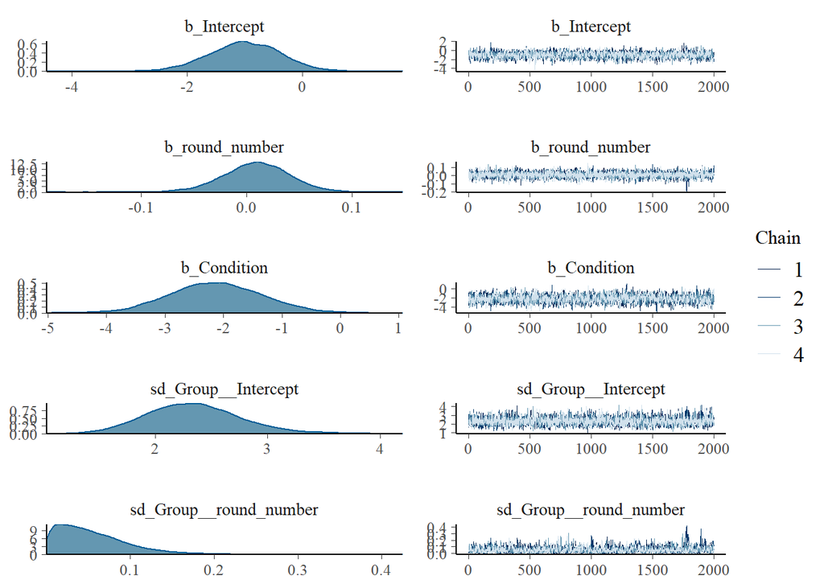

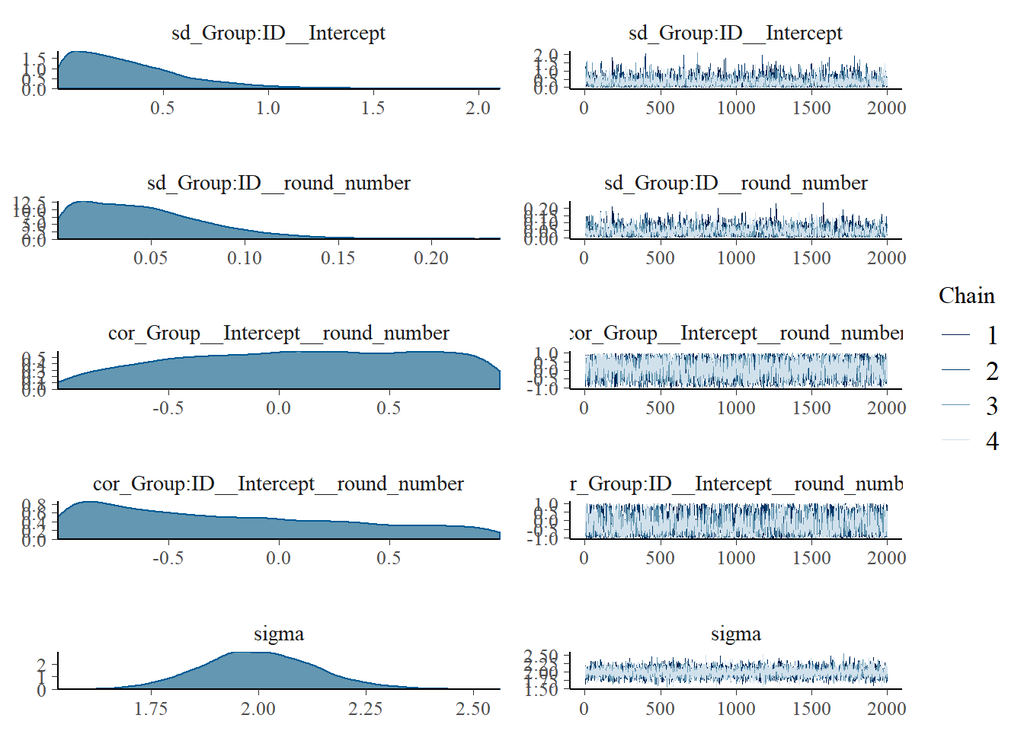

What’s the posterior `diff` score for participants in the Visible condition?

```
##  2.5%   50% 97.5%
## -2.26 -1.00  0.19
```

The model estimates that participants in the Visible condition give, on average, 1 cattle less than was requested. What about participants in the Hidden condition?

```
##  2.5%   50% 97.5%
## -4.34 -3.13 -1.91
```

Participants in the Hidden condition give 3 cattle less than was requested, on average.